# A Brief Analysis of Public Education in North Carolina

Colin Nguyen

2025-07-09

# Abstract

Growing up in North Carolina, I spent the majority of my life in a small town in the Piedmont region. This part of the state is between the mountain region and the coastal plains, and is characterized by its popularity for farming and development due to its fertile soils and rolling hills. The Piedmont weather is known to be milder than its counterparts, as winters in the mountains were extremely cold and summers near the coast were very humid. Historically, this is also the region where North Carolina’s Gold Rush was the strongest. Perhaps these are some of the reasons why the Piedmont region is home to the majority of the state’s population. Most of North Carolina’s biggest and most important cities, like Charlotte, Raleigh, and Winston-Salem, are located in this region. My earliest years of childhood were spent in the outskirts of Charlotte before I moved farther away to a smaller town. However, even though I was young, I still noticed how different the schools felt. As I got older, I only realized more of these differences- the schools looked newer, they seemed to have more money, and test scores were higher. But was this all true?

In my later years of high school I was able to see more of my home state. Every time we’d drive past another school I liked to imagine what it would be like to go there every day. Many of those schools looked old and worn-down compared to the schools in my county. When I traveled more, I started to realize that I failed to think about how different the rest of the state was, and how each one had a story that I wanted it to tell me. How do these schools compare to mine? Are their test scores higher, lower, or similar? Why so? To find out, I gathered data on all 115 school districts in North Carolina to see what patterns, if any, arise.

# Ethical Considerations

I will be using a dataset that I compiled all of the data for, but it is important to note that all of the data came from US New and World Reports, which I do not own. I did not gather the data myself, and I do not claim any ownership over it. This is merely a personal and independent project to answer some questions that I’ve had for a while .I also need to mention the timeframe when this data was gathered- much of this data was collected as recently as 2023 or as far back as 2018. It is important for us to realize that during 2019-2020 many schools were affected by COVID-19, and some may have not updated their information since. So we must know that our findings here may not tell the most complete story, and there will certainly be details missing from the final picture.

Potential stakeholders in this research include the students and families of these school districts in North Carolina, as well as educators, counselors, school board representatives and workers, and academic policymakers. All of these people can look into this data to learn more about the education that are being given to our children, and it can possibly be used to navigate solutions to help improve any unfavorable conditions. Like it did for me, it can help others put their life into a greater perspective in respect to others, and it makes one realize that lives can very substantially even in the same state. However, we must note the realism of this data, in that many families cannot simply move to a better-performing school due to extenuating circumstances, or perhaps some schools lack resources needed for improvement. We should also keep in mind that any findings are not wholly indicative of every single student’s academic success- just because a school has low test scores does not mean that every student there struggles academically. This data analysis is in no way intended to shame anybody or the way they live.

Let it be known that no students are identified and that all student data is completely anonymous and not on an individual level.

# Methods

### 3. Actual Analysis

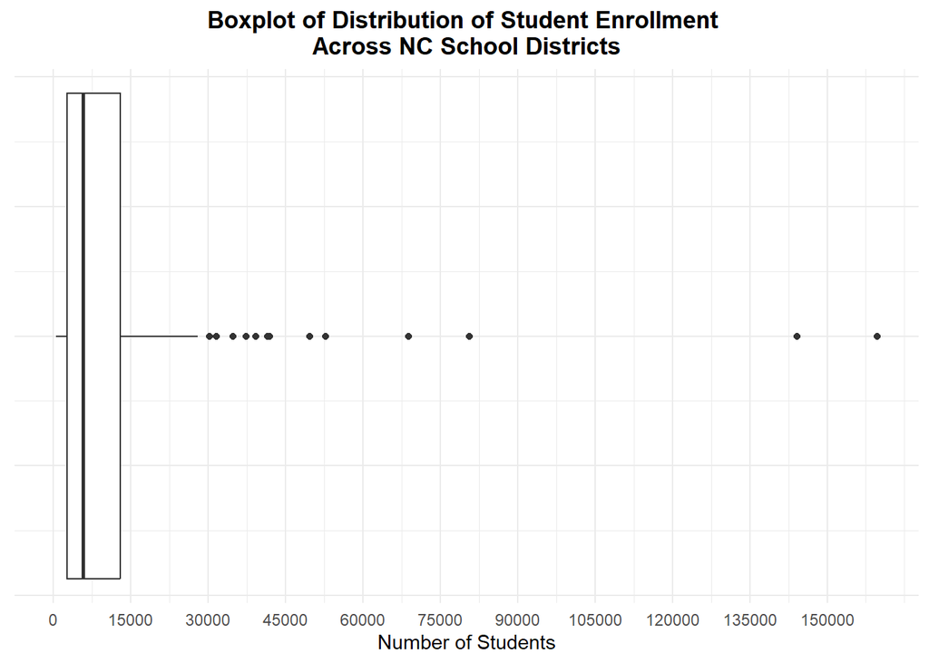

```r
ggplot(education2, aes(x = Number.of.Students, )) +
  geom_boxplot() +
    labs(
      title = "Boxplot of Distribution of Student Enrollment \nAcross NC School Districts",
      x = "Number of Students"
    )+
    theme_minimal()+
    theme(
      axis.text.y = element_blank(),  # Removes the y-axis tick labels
      plot.title = element_text(hjust = 0.5, face = 'bold')
    ) +
  scale_x_continuous(breaks = seq(0, 160000, by = 15000))
```

This boxplot shows the distribution of the amount of students in each of the school districts- it’s amazing to see how large some of North Carolina’s schools can be, with outliers reaching beyong 135,000 students, rivalling the size of a few universities. In contrast, the smallest school district has only 475 students. The median, which was found through summary() since it’s hard to see on the boxplot, is around 5,776, and 50% of school districts have between 2,652 and 12,920 students (see below).

```r
summary(education2$Number.of.Students)
```

```
##    Min. 1st Qu.  Median    Mean 3rd Qu.    Max.
##     475    2652    5776   13391   12920  159778
```

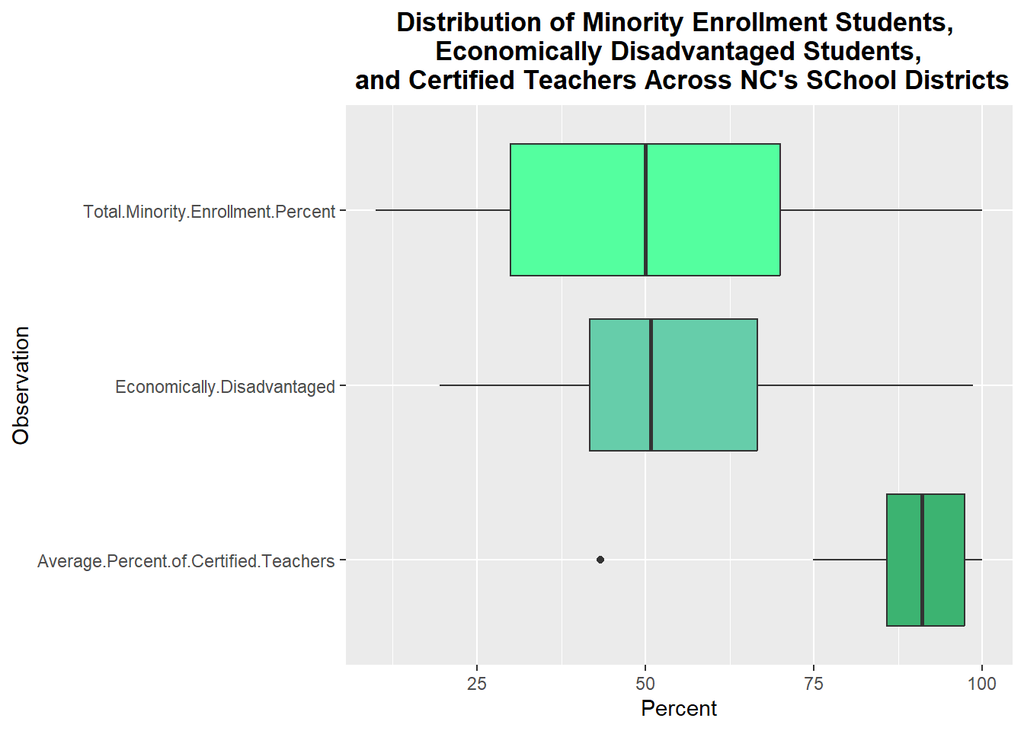

```r
mini_ed1 <- education2[c(5,13,14)]
mini_ed1 <- mini_ed1 %>%
  mutate_if(is.character, as.numeric)
# Assuming 'my_data' is your dataframe
data_long <- mini_ed1 %>% pivot_longer(cols = everything(), names_to = "variable", values_to = "value")

ggplot(data_long, aes(y = variable, x = value, fill = variable)) +
  geom_boxplot() +
  labs(title = "Distribution of Minority Enrollment Students, \n Economically Disadvantaged Students, \n and Certified Teachers Across NC's SChool Districts", x = "Percent", y = "Observation") +
  theme(legend.position = "none",
        plot.title = element_text(hjust=0.5, face='bold')) +
  scale_fill_manual(values=c("mediumseagreen","mediumaquamarine","seagreen1"))
```

These boxplots show the distributions of the total minority enrollment, total percent of economically disadvantaged students, and the average percent of certified teachers across all of North Carolina’s school districts. The total minority enrollment distribution seems pretty balanced as the median is around 50% minority enrollment, with 50% of NC schools have lower minority enrollments and 50% having higher numbers. Half of all school districts fall between having around 30% and 70% minority enrollment. The distribution of economically disadvantaged students has a much lower interquartile range but a similar median around the 50% mark, with half of all schools having between 40% and 65% percentages. The distribution of the percent of certified teachers is much higher than the previous two, with a median around 90%. Half of all schools have between 87% and 95% of their teachers certified, with a minimum of about 75%. Notably, there is also an outlier of a school district that has less than 50% of their teachers certified.

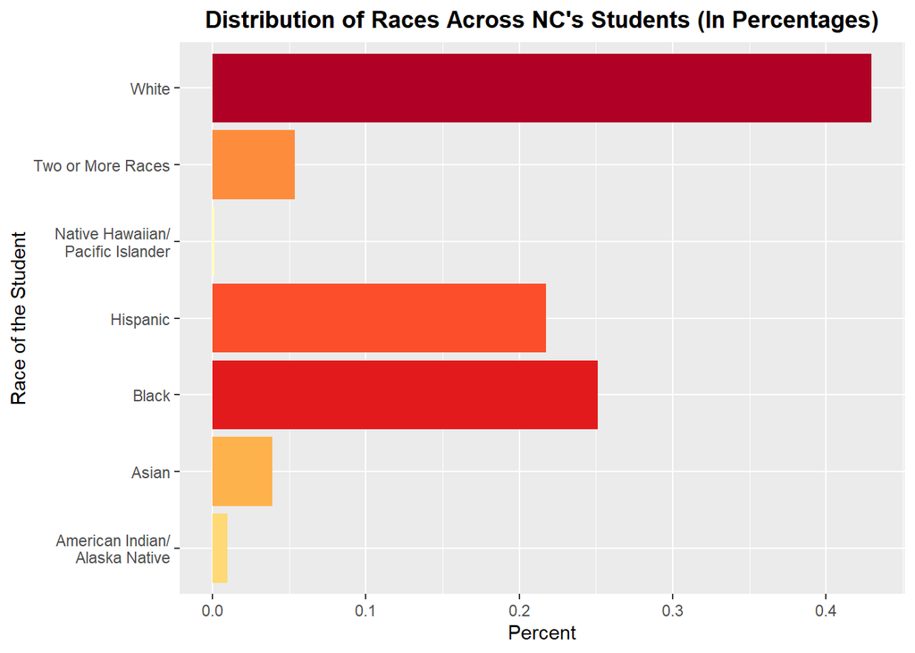

```r
#make a new column that mulitplies each race by the total amount and then make a bar graph
mini_ed3 <- education2
var<- mini_ed3 %>% mutate(
  White.Amount=(Percent.of.White.Students/100)*Number.of.Students,
  Black.Amount=(Percent.of.Black.Students/100)*Number.of.Students,
  Hispanic.Amount=(Percent.of.Hispanic.Students/100)*Number.of.Students,
  Asian.Amount=(Percent.of.Asian.Students/100)*Number.of.Students,
  Two.or.More.Amount=(Two.or.More.Races/100)*Number.of.Students,
  AIAN.Amount=(American.Indian.Alaska.Native/100)*Number.of.Students,
  NHPI.Amount=(Native.Hawaiian.Pacific.Islander/100)*Number.of.Students
  )

total <- sum(var$Number.of.Students)
white <- (sum(var$White.Amount))/total
black <- (sum(var$Black.Amount))/total
hispanic <- (sum(var$Hispanic.Amount))/total
asian <- (sum(var$Asian.Amount))/total
twomore <- (sum(var$Two.or.More.Amount))/total
aian <- (sum(var$AIAN.Amount))/total
nhpi <- (sum(var$NHPI.Amount))/total

races <- c(white, black, hispanic, asian, twomore, aian, nhpi)
lbls <- c('White', 'Black', 'Hispanic', 'Asian', 'Two or More Races', 'American Indian/Alaska Native', 'Native Hawaiian/\nPacific Islander')

percentages <- round(races*100)
lbls <- paste(lbls, percentages)

race_data <- data.frame(
  races <- c(white, black, hispanic, asian, twomore, aian, nhpi),
  lbls <- c('White', 'Black', 'Hispanic', 'Asian', 'Two or More Races', 'American Indian/\nAlaska Native', 'Native Hawaiian/\nPacific Islander')
)

ggplot(race_data, aes(x=lbls, y=races, fill=as.factor(races))) +
  geom_bar(stat="identity") +
  labs(
    title = "Distribution of Races Across NC's Students (In Percentages)",
    x = "Race of the Student",
    y = "Percent"
  ) +
  scale_fill_brewer(palette="YlOrRd") +
  theme(legend.position = "none") +
  coord_flip() +
  theme(legend.position = "none",
        plot.title = element_text(hjust=0.5, face='bold'))
```

Here is a visual showing the distribution of races among the student populations of North Carolina’s school districts; do note how these are representing percentages. It appears that the largest racial group is comprised of white students, with the second-largest being the number of black students, followed by Hispanic students. After those three significantly larger groups comes those who identify as two or more races, then Asian students, then American Indian/Alaska Native students and finally Native Hawaiian/Pacific Islander students. This is not very surprising as it very closely matches the racial distribution of North Carolina as a state on the whole, and growing up in North Carolina’s public schools, this visualization harbors no surprises for me.

### 4. Linear Regression Models

#### High School Math Proficiency

```r
test <- education %>%
  drop_na(High.School.Math.Proficiency, Total.Revenue, Average.Percent.of.Certified.Teachers)
nrow(test)
```

```
## [1] 112
```

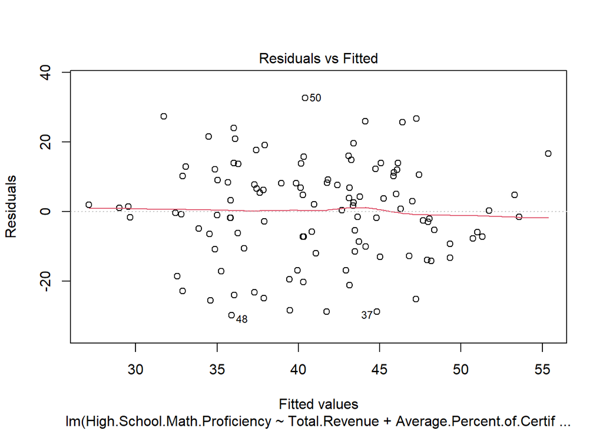

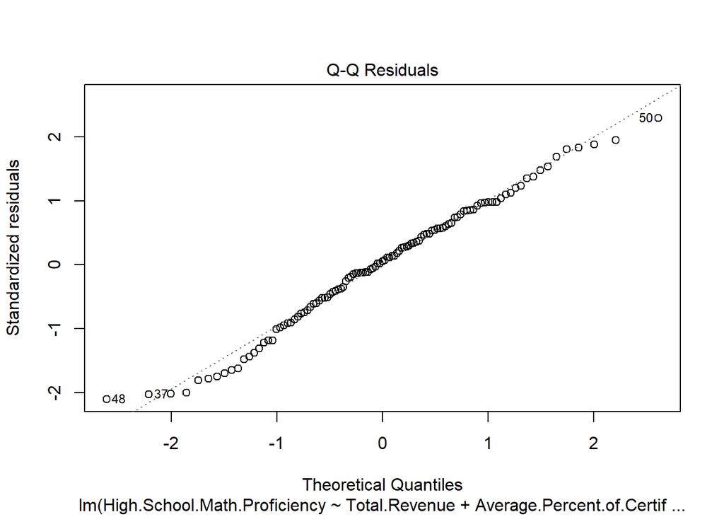

```r
model <- lm(High.School.Math.Proficiency ~ Total.Revenue + Average.Percent.of.Certified.Teachers + Economically.Disadvantaged + Number.of.Full.Time.Counselors, test)
plot(model, which=c(1, 2))
```

```r
summary(model)
```

```
##
## Call:
## lm(formula = High.School.Math.Proficiency ~ Total.Revenue + Average.Percent.of.Certified.Teachers +
##     Economically.Disadvantaged + Number.of.Full.Time.Counselors,
##     data = test)
##
## Residuals:
##     Min      1Q  Median      3Q     Max
## -29.896  -9.035   0.706   9.634  32.586
##
## Coefficients:
##                                         Estimate Std. Error t value Pr(>|t|)
## (Intercept)                            5.346e+01  1.731e+01   3.089 0.002566
## Total.Revenue                         -6.637e-08  4.303e-08  -1.542 0.125990
## Average.Percent.of.Certified.Teachers  1.061e-01  1.692e-01   0.627 0.531918
## Economically.Disadvantaged            -3.790e-01  9.751e-02  -3.887 0.000177
## Number.of.Full.Time.Counselors         3.114e-01  2.370e-01   1.314 0.191706
##
## (Intercept)                           **
## Total.Revenue
## Average.Percent.of.Certified.Teachers
## Economically.Disadvantaged            ***
## Number.of.Full.Time.Counselors
## ---
## Signif. codes:  0 '***' 0.001 '**' 0.01 '*' 0.05 '.' 0.1 ' ' 1
##
## Residual standard error: 14.36 on 106 degrees of freedom
##   (1 observation deleted due to missingness)
## Multiple R-squared:  0.148,  Adjusted R-squared:  0.1159
## F-statistic: 4.604 on 4 and 106 DF,  p-value: 0.001817
```

#### High School Reading Proficiency

```r
test2 <- education %>%
  drop_na(High.School.Reading.Proficiency, Total.Revenue, Average.Percent.of.Certified.Teachers)
nrow(test2)
```

```
## [1] 114
```

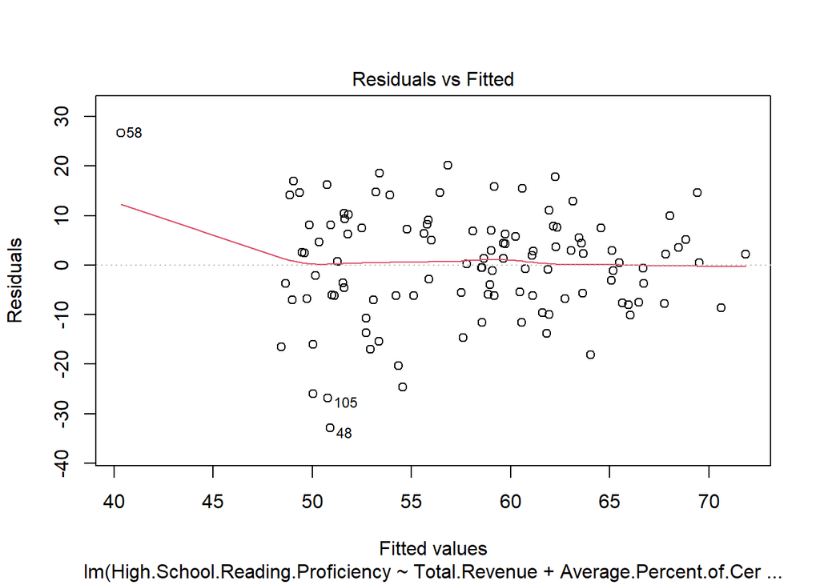

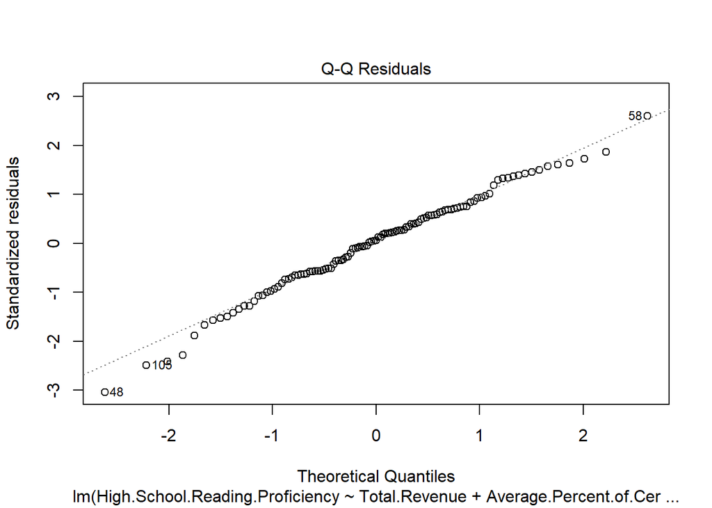

```r
model2 <- lm(High.School.Reading.Proficiency ~ Total.Revenue + Average.Percent.of.Certified.Teachers + Economically.Disadvantaged + Number.of.Full.Time.Counselors, test2)
plot(model2, which=c(1, 2))
```

```r
summary(model2)
```

```
##
## Call:
## lm(formula = High.School.Reading.Proficiency ~ Total.Revenue +
##     Average.Percent.of.Certified.Teachers + Economically.Disadvantaged +
##     Number.of.Full.Time.Counselors, data = test2)
##
## Residuals:
##     Min      1Q  Median      3Q     Max
## -32.908  -6.227   0.734   7.225  26.652
##
## Coefficients:
##                                         Estimate Std. Error t value Pr(>|t|)
## (Intercept)                            7.171e+01  1.310e+01   5.473 2.90e-07
## Total.Revenue                         -2.629e-08  3.278e-08  -0.802    0.424
## Average.Percent.of.Certified.Teachers  9.050e-02  1.279e-01   0.708    0.481
## Economically.Disadvantaged            -4.126e-01  7.385e-02  -5.587 1.75e-07
## Number.of.Full.Time.Counselors         1.446e-01  1.805e-01   0.801    0.425
##
## (Intercept)                           ***
## Total.Revenue
## Average.Percent.of.Certified.Teachers
## Economically.Disadvantaged            ***
## Number.of.Full.Time.Counselors
## ---
## Signif. codes:  0 '***' 0.001 '**' 0.01 '*' 0.05 '.' 0.1 ' ' 1
##
## Residual standard error: 10.94 on 108 degrees of freedom
##   (1 observation deleted due to missingness)
## Multiple R-squared:  0.2574, Adjusted R-squared:  0.2299
## F-statistic: 9.357 on 4 and 108 DF,  p-value: 1.567e-06
```

#### Middle School Math Proficiency

```r
test3 <- education %>%
  drop_na(Middle.School.Math.Proficiency, Total.Revenue, Average.Percent.of.Certified.Teachers)
nrow(test3)
```

```
## [1] 115
```

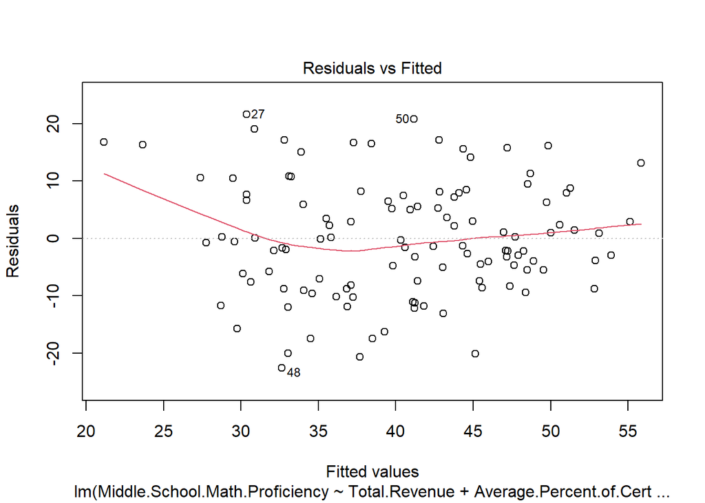

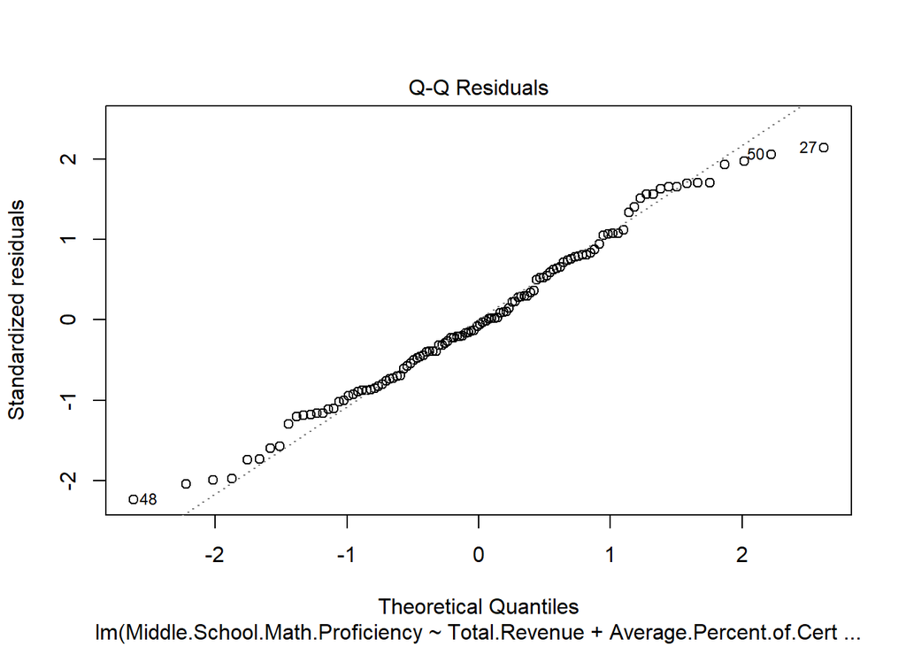

```r
model3 <- lm(Middle.School.Math.Proficiency ~ Total.Revenue + Average.Percent.of.Certified.Teachers + Economically.Disadvantaged + Number.of.Full.Time.Counselors, test3)
plot(model3, which=c(1, 2))
```

```r
summary(model3)
```

```
##
## Call:
## lm(formula = Middle.School.Math.Proficiency ~ Total.Revenue +
##     Average.Percent.of.Certified.Teachers + Economically.Disadvantaged +
##     Number.of.Full.Time.Counselors, data = test3)
##
## Residuals:
##      Min       1Q   Median       3Q      Max
## -22.6460  -7.4193  -0.6801   7.4162  21.6397
##
## Coefficients:
##                                         Estimate Std. Error t value Pr(>|t|)
## (Intercept)                            3.628e+01  1.205e+01   3.011  0.00323
## Total.Revenue                         -3.552e-08  3.065e-08  -1.159  0.24890
## Average.Percent.of.Certified.Teachers  3.105e-01  1.183e-01   2.625  0.00990
## Economically.Disadvantaged            -4.466e-01  6.770e-02  -6.597 1.56e-09
## Number.of.Full.Time.Counselors         1.905e-01  1.688e-01   1.129  0.26140
##
## (Intercept)                           **
## Total.Revenue
## Average.Percent.of.Certified.Teachers **
## Economically.Disadvantaged            ***
## Number.of.Full.Time.Counselors
## ---
## Signif. codes:  0 '***' 0.001 '**' 0.01 '*' 0.05 '.' 0.1 ' ' 1
##
## Residual standard error: 10.23 on 109 degrees of freedom
##   (1 observation deleted due to missingness)
## Multiple R-squared:  0.3609, Adjusted R-squared:  0.3375
## F-statistic: 15.39 on 4 and 109 DF,  p-value: 5.23e-10
```

#### Middle School Reading Proficiency

```r
test4 <- education %>%
  drop_na(Middle.School.Reading.Proficiency, Total.Revenue, Average.Percent.of.Certified.Teachers)
nrow(test4)
```

```
## [1] 115
```

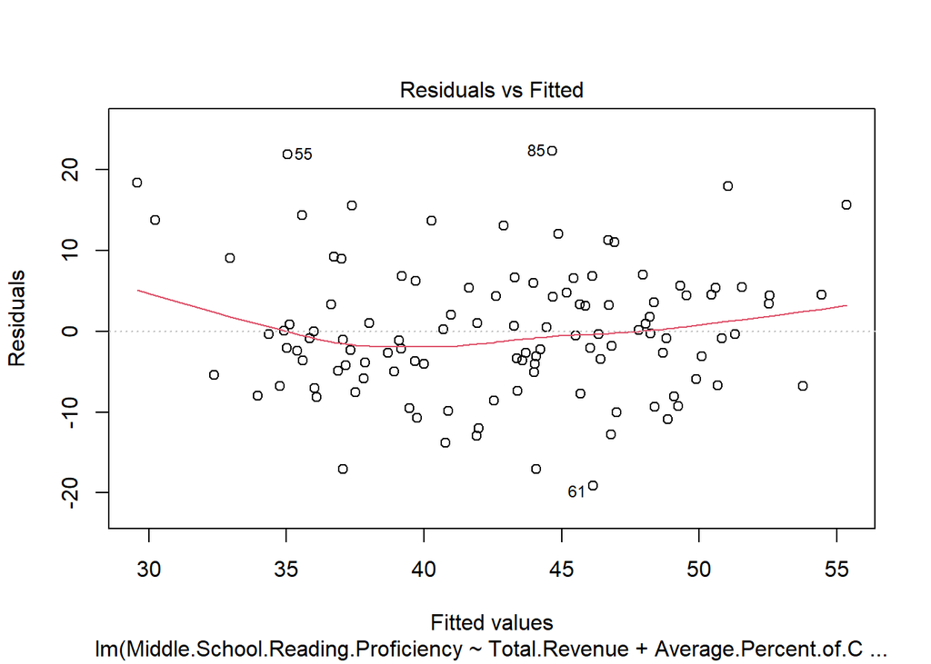

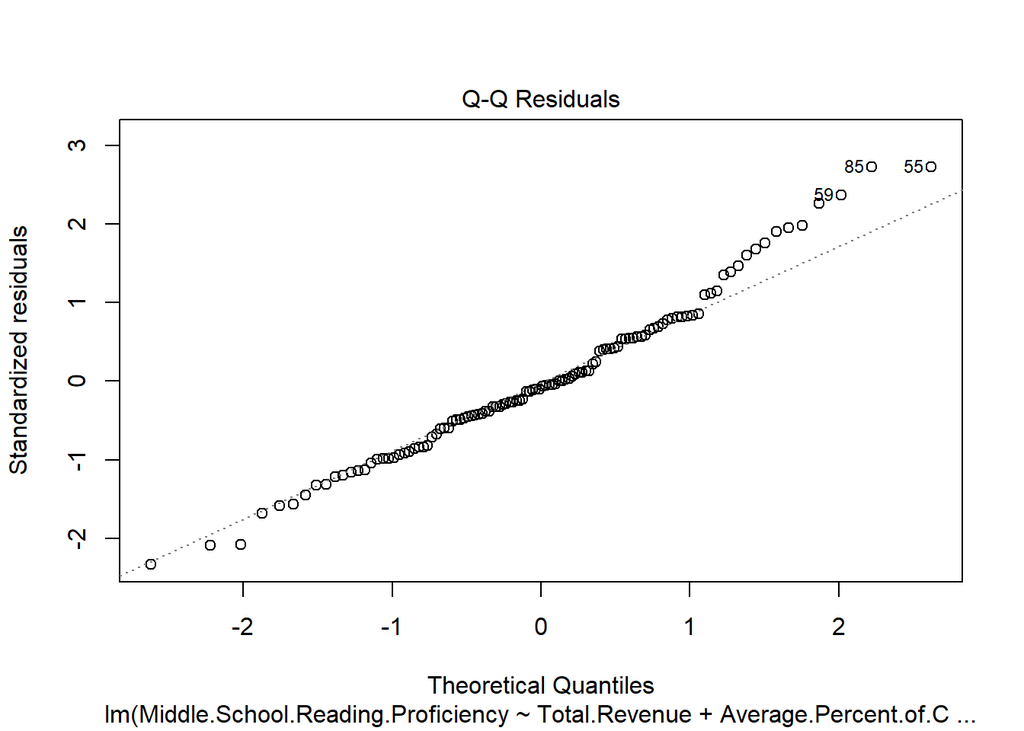

```r
model4 <- lm(Middle.School.Reading.Proficiency ~ Total.Revenue + Average.Percent.of.Certified.Teachers + Economically.Disadvantaged + Number.of.Full.Time.Counselors, test4)
plot(model4, which=c(1, 2))
```

```r
summary(model4)
```

```
##
## Call:
## lm(formula = Middle.School.Reading.Proficiency ~ Total.Revenue +
##     Average.Percent.of.Certified.Teachers + Economically.Disadvantaged +
##     Number.of.Full.Time.Counselors, data = test4)
##
## Residuals:
##     Min      1Q  Median      3Q     Max
## -19.140  -4.993  -0.667   4.558  22.341
##
## Coefficients:
##                                         Estimate Std. Error t value Pr(>|t|)
## (Intercept)                            4.483e+01  9.765e+00   4.591 1.19e-05
## Total.Revenue                         -4.400e-08  2.484e-08  -1.772   0.0793
## Average.Percent.of.Certified.Teachers  1.924e-01  9.586e-02   2.008   0.0472
## Economically.Disadvantaged            -3.542e-01  5.487e-02  -6.456 3.07e-09
## Number.of.Full.Time.Counselors         2.362e-01  1.368e-01   1.727   0.0871
##
## (Intercept)                           ***
## Total.Revenue                         .
## Average.Percent.of.Certified.Teachers *
## Economically.Disadvantaged            ***
## Number.of.Full.Time.Counselors        .
## ---
## Signif. codes:  0 '***' 0.001 '**' 0.01 '*' 0.05 '.' 0.1 ' ' 1
##
## Residual standard error: 8.289 on 109 degrees of freedom
##   (1 observation deleted due to missingness)
## Multiple R-squared:  0.3341, Adjusted R-squared:  0.3097
## F-statistic: 13.67 on 4 and 109 DF,  p-value: 4.56e-09
```

#### Elementary School Math Proficiency

```r
test5 <- education %>%
  drop_na(Elementary.School.Math.Proficiency, Total.Revenue, Average.Percent.of.Certified.Teachers)
nrow(test5)
```

```
## [1] 115
```

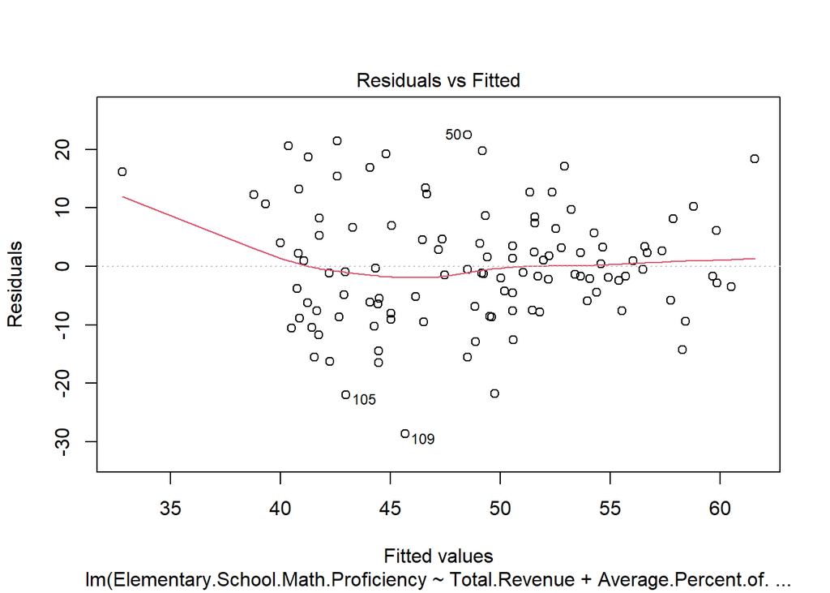

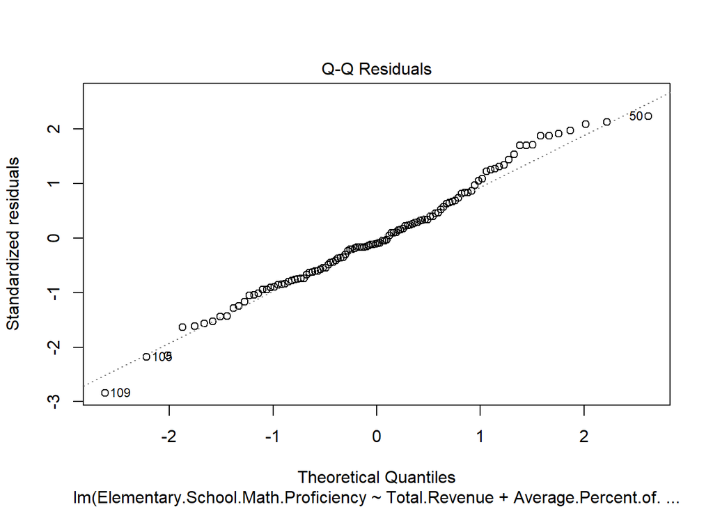

```r
model5 <- lm(Elementary.School.Math.Proficiency ~ Total.Revenue + Average.Percent.of.Certified.Teachers + Economically.Disadvantaged + Number.of.Full.Time.Counselors, test5)
plot(model5, which=c(1, 2))
```

```r
summary(model5)
```

```
##
## Call:
## lm(formula = Elementary.School.Math.Proficiency ~ Total.Revenue +
##     Average.Percent.of.Certified.Teachers + Economically.Disadvantaged +
##     Number.of.Full.Time.Counselors, data = test5)
##
## Residuals:
##     Min      1Q  Median      3Q     Max
## -28.659  -6.739  -1.095   6.052  22.489
##
## Coefficients:
##                                         Estimate Std. Error t value Pr(>|t|)
## (Intercept)                            5.705e+01  1.200e+01   4.755 6.10e-06
## Total.Revenue                         -7.685e-09  3.051e-08  -0.252    0.802
## Average.Percent.of.Certified.Teachers  1.309e-01  1.178e-01   1.111    0.269
## Economically.Disadvantaged            -3.792e-01  6.740e-02  -5.626 1.45e-07
## Number.of.Full.Time.Counselors         3.541e-02  1.680e-01   0.211    0.833
##
## (Intercept)                           ***
## Total.Revenue
## Average.Percent.of.Certified.Teachers
## Economically.Disadvantaged            ***
## Number.of.Full.Time.Counselors
## ---
## Signif. codes:  0 '***' 0.001 '**' 0.01 '*' 0.05 '.' 0.1 ' ' 1
##
## Residual standard error: 10.18 on 109 degrees of freedom
##   (1 observation deleted due to missingness)
## Multiple R-squared:  0.263,  Adjusted R-squared:  0.236
## F-statistic: 9.725 on 4 and 109 DF,  p-value: 9.171e-07
```

#### Elementary School Reading Proficiency

```r
test6 <- education %>%
  drop_na(Elementary.School.Reading.Proficiency, Total.Revenue, Average.Percent.of.Certified.Teachers)
nrow(test6)
```

```
## [1] 115
```

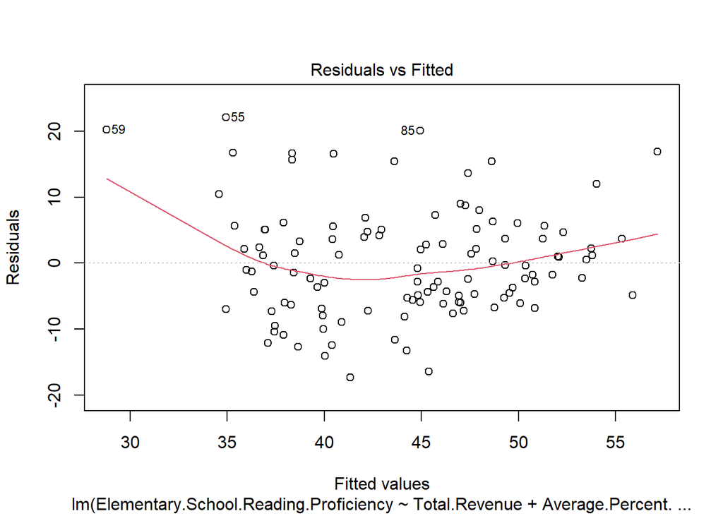

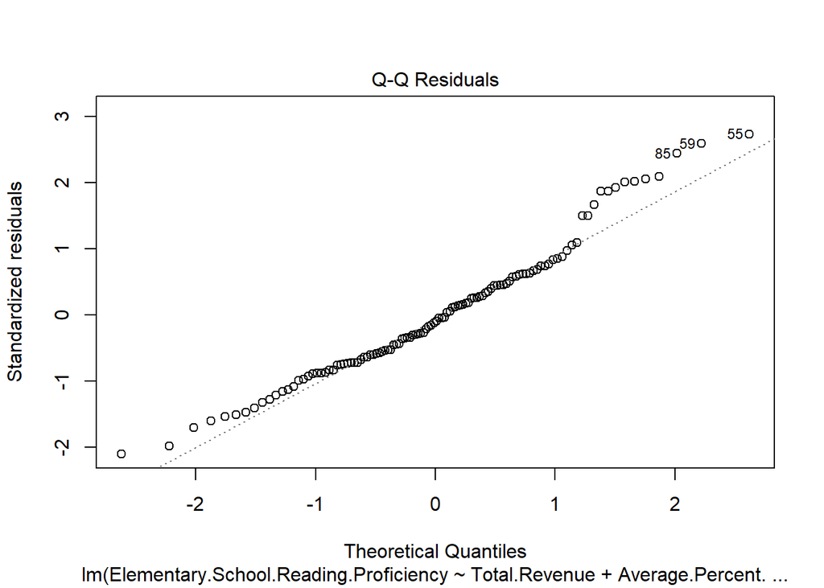

```r
model6 <- lm(Elementary.School.Reading.Proficiency ~ Total.Revenue + Average.Percent.of.Certified.Teachers + Economically.Disadvantaged + Number.of.Full.Time.Counselors, test6)
plot(model6, which=c(1, 2))
```

```r
summary(model6)
```

```
##
## Call:
## lm(formula = Elementary.School.Reading.Proficiency ~ Total.Revenue +
##     Average.Percent.of.Certified.Teachers + Economically.Disadvantaged +
##     Number.of.Full.Time.Counselors, data = test6)
##
## Residuals:
##      Min       1Q   Median       3Q      Max
## -17.3405  -5.9291  -0.8945   4.7604  22.0764
##
## Coefficients:
##                                         Estimate Std. Error t value Pr(>|t|)
## (Intercept)                            5.334e+01  9.823e+00   5.430 3.45e-07
## Total.Revenue                         -2.822e-08  2.498e-08  -1.130    0.261
## Average.Percent.of.Certified.Teachers  1.235e-01  9.643e-02   1.281    0.203
## Economically.Disadvantaged            -3.769e-01  5.519e-02  -6.829 5.07e-10
## Number.of.Full.Time.Counselors         1.456e-01  1.376e-01   1.059    0.292
##
## (Intercept)                           ***
## Total.Revenue
## Average.Percent.of.Certified.Teachers
## Economically.Disadvantaged            ***
## Number.of.Full.Time.Counselors
## ---
## Signif. codes:  0 '***' 0.001 '**' 0.01 '*' 0.05 '.' 0.1 ' ' 1
##
## Residual standard error: 8.338 on 109 degrees of freedom
##   (1 observation deleted due to missingness)
## Multiple R-squared:  0.3368, Adjusted R-squared:  0.3125
## F-statistic: 13.84 on 4 and 109 DF,  p-value: 3.687e-09
```

For each of the linear regression models above, I checked if the variables that I picked for analysis (total revenue of the school district, the average percent of certified teachers, the amount of economically disadvantaged students, and the number of full-time counselors) were fit to use for multiple linear regression. To do this, I used the Q-Q plot to check if the data was normally distributed- the points on the graph lined up pretty well with the diagonal line overall, and so this condition is satisfied. I also used a residuals vs. fitted plot to make sure that the relationship was linear and all the data is random and independent. None of these residual plots show any signs of major homoskedasticity, and while there were a few outliers, the red line was mostly close to being flat for most of the data, so these conditions are almost met.

# Conclusion

In this paper I looked to see if there were any patterns that arose between the conditions of a school district and how they performed. First of all, I looked at some basic summary statistics of North Carolina’s 115 school districts for a snapshot of what I’m going to be looking at. North Carolina’s schools have a median of around fifty percent for both total minority enrollment and the percent of economically disadvantaged students. Most teachers are certified, but there is an outlier that’s far below the usual amount of all the other districts. The largest student racial group consists of white students, followed by black student, followed by Hispanic students. Then other groups like Asian, Native American, Pacific Islander, and those who identify as two or more races are far below in numbers.

First of all, further analysis must be done on the total revenue of the school districts as each one allocates their funds in different ways. One school district may receive more funding that another, but may have to spend more on utilities and maintenance compared to instruction. We also must remember that correlation does not necessarily imply causation- just because a school district has a higher amount of economically disadvantaged students does not mean that they will perform worse than others. However, there could potentially be a relationship here- we can guess that if a student is economically disadvantaged and therefore qualifies for free/reduced lunch, then their family would likely not have the means to afford their kids tutors and study materials. Perhaps their families don’t have the time, resources, or ability to be able to drive their kid to after-school mentoring programs, or extracurricular activities that can benefit their children’s learning. It’s common for parents to have to work a lot to support their families, and so they lay responsibility to their kids to care for their siblings and the house, leaving them with less time to study and worry about extra school. While this is plausible, it certainly can’t be true for everyone, but it does fuel further thought on finances and how they can affect a child’s education.

So what can be done? It’s hard for me to say that there’s a clear solution when I myself don’t know the full picture yet. It would be easy to say that a school district should allocate more of their funds to instruction and providing more resources to lower-income children, but there is always something there that can complicate this. However, I do think this will be a possible start to a solution. As for students who come from low-income backgrounds, there are possible ways to supplement learning for free. Using free online resources, like YouTube and Khan Academy, are great ways to learn concepts for better understanding. If possible, asking for the teacher for extra help during the school day can eliminate the need to stay after school. There are major problems with these proposed fixes, though, that I must acknowledge. My first solution would not work for those who either don’t have access to their own technology, their family doesn’t have the technology, or if their household doesn’t have reliable internet connections. Also, I mentioned that time is such an important factor, and for some, this still may not be possible. The second solution is not as problematic as the first, but perhaps the teacher doesn’t have enough time to cater towards every student’s individual needs, maybe because there are so many students and not enough staff.

It may be difficult to find a perfect solution (or even the best) and it may be even harder to actually implement it, but it’s important to remember two things. Firstly, school test scores are not strict indicators of a person’s ability to succeed in life. Test scores, on both an individual and district level, absolutely has nothing to do with one’s worth. Secondly, any step towards improvement, no matter how small or seemingly insignificant, is important. Grandiose solutions won’t appear without taking those first few starter steps. I hope that by analyzing all of this data that I can help in being part of one of those first steps through telling a story.